# Ford GoBike tripdata Exploration

### Notebook by: *Ahmed Esmat*

## Investigation Overview

> The Investigation aims to get some insights about bike sharing trips details through exploring the main trips data features, getting a clear relationships of features and therefore communicate a useful notes or information about the data.

## Background

> The data set includes information about individual rides made in a bike-sharing system covering the greater San Francisco Bay area by Ford GoBike.  
> Ford GoBike is the Bay Area's bike share system. Bay Area Bike Share was introduced in 2013 as a pilot program for the region, with 700 bikes and 70 stations across San Francisco and San Jose ... [continue reading](https://www.crunchbase.com/organization/gobike)

## Dataset Overview

[figure not shown]

> It is a 1-month data of trips with more than 180000 record. The data was messy, have inapproperiate feeatures data types and missing values, specifically in members gender, birth year and station names.

## Data Wrangling

> - The features data types were corrected. Then, a trial to recover station names using available staion coordinates, but in vain. These data was dropped.
> - Missing member gender and birth year date was dropped and Some outliers were handled based on condition.
> - Some Features were add such as distance between start and end stations (using stations' coordinates), trip speed, member Age and the day of the month.

> Are you ready for a trip to get some insights from this dataset?

### Distribution of FORD bikes riders' gender, type and age

> More Than 90% of our FORD bikes riders are using subscribtion services, Males are the main gender with ~75% while ~2% of bike riders prefer not to tell about gender. It is clearly showen in the age distribution that the minimun age of travellers are 20 years, This may support a regulation set for bike riders or a data cut setting 20 years old as a threshold, while the majority of riders' age varies between 27 ~ 37 years old.

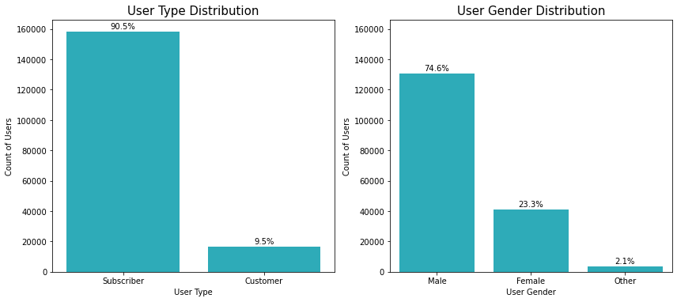

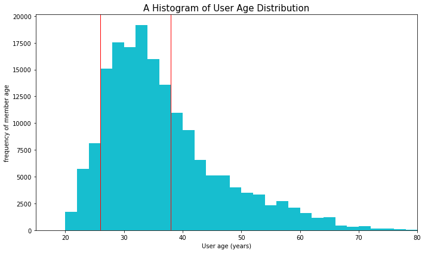

### Distribution of Trips' Duration, Distance and Speed

> Plotted on a logarithmic scale, The majority of trips lasts for (250 ~ 1000 secs), while the majority of trips moves in a distance between (0.8 ~ 2.5 Km). Calculated trips speed varies between (8 ~ 14 Km/hr).

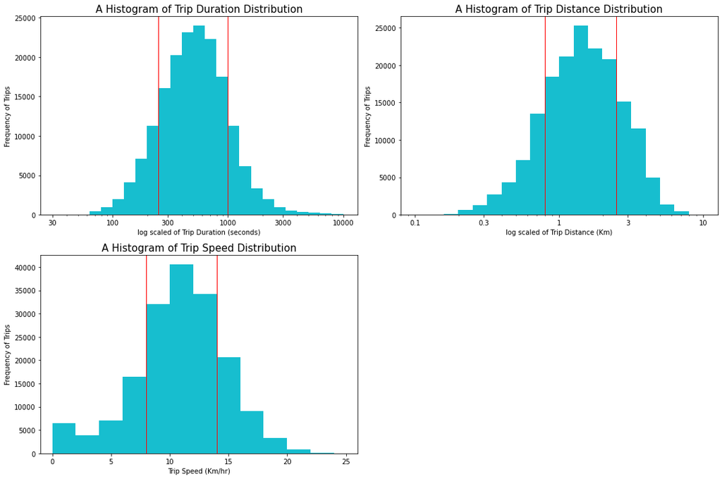

### Distribution of Member Age vs Gender and User Type

> Using Violin plots, Females mean age is slightly low in compare with Males and other. While, unknown/other gender showing a peak at ages between 50 and 60 years. Customers and Subscribers almost showing the same age distributions.

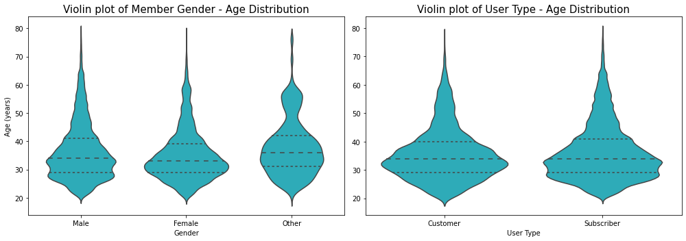

### The most frequent days of the month with respect to user type

> Using Violin and Box plots, Subscribers are distributed equally overall the month with some peaks on weekly basis, the pattern suggest normal weekend trips. For Customers, the pattern showing a service higher request rate at the second half of the month. It may reflect a non-routine work or bi-weekly work basis pattern.

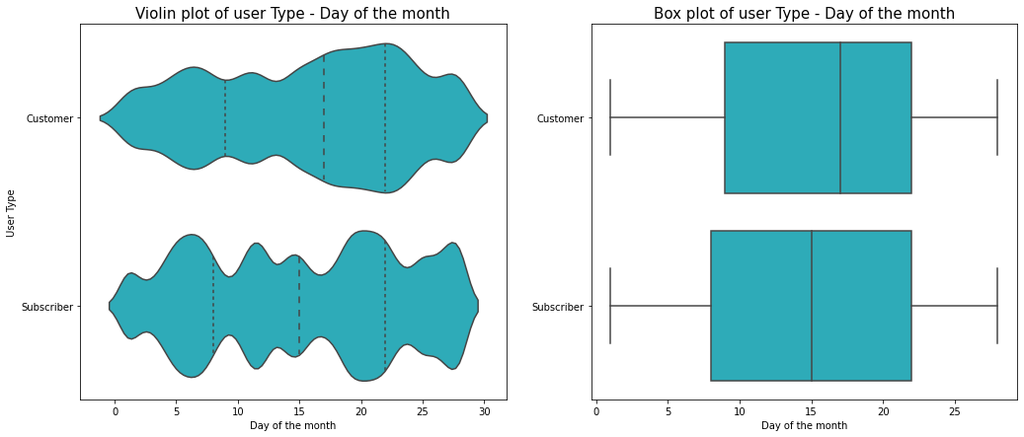

### the relation between trip distance and trip duration with corresponding member gender and User type

> A linear positive relationships with a logarithmic scale plotting, for the trip distance and trip duration for both member gender and user type. While exculding the outliers at higher trip duration, the customer/undefined gender relationship is quiet strong in positive direction.

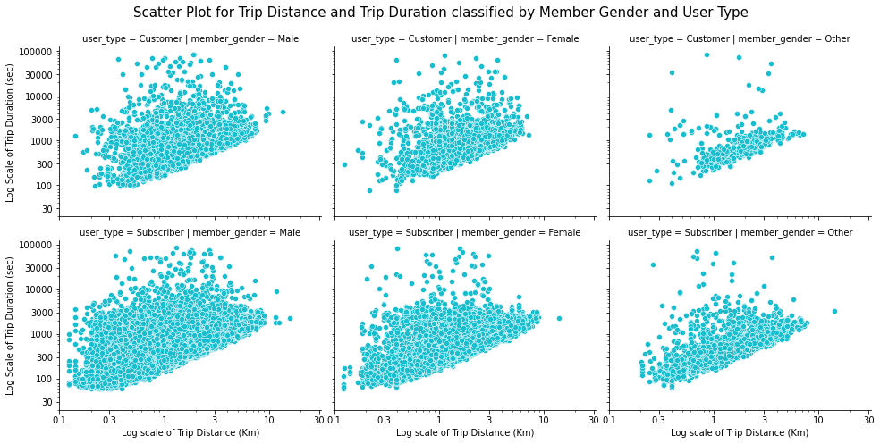

### the relation between day of the month and average trip speed vs both member gender and user type

> Generally, overall the month, The subscribers' average trip speed is higher than customers. Also, The average travelling speed by Males is higher than Females.

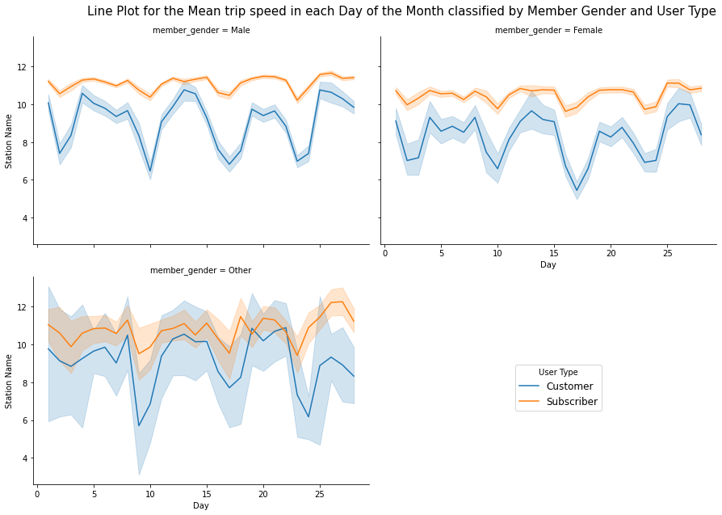

### Thank You :)